# Week1: Linear Models

# Objective

This homework sheet will help reviewing the basic concepts associated with linear regression models. Please review the lectures, suggested readings, and additional resources **before** getting started on the HW

**Some questions in this assignment will require you to conduct independent research beyond the material covered in the recorded content.**

**Questions**

This homework is divided into two main parts. First, a conceptual component will review the basic concepts related to linear models. The second part of the homework is mostly intended to be a brief introduction to fitting and analyzing linear models in Python. Several of these questions are modified from James et al. (2021).

Marks Distribution

| Question | Marks |
| --- | --- |
| 1 | 1 |
| 2a | 0.25 |
| 2b | 0.25 |
| 2c | 0.25 |
| 2d | 0.25 |
| 3a | 0.25 |
| 3b | 0.25 |
| 3c | 0.25 |
| 3d | 0.25 |
| 4a.i | 0.25 |
| 4a.ii | 0.25 |
| 4a.iii | 0.25 |
| 4a.iv | 0.50 |
| 4a.v | 0.25 |
| 4a.vi | 0.50 |
| 4b | 0.50 |
| 4c | 0.50 |
| 5a | 0.25 |
| 5b | 0.25 |
| 5c.i | 0.25 |
| 5c.ii | 0.25 |
| 5c.iii | 0.25 |
| 5d | 0.25 |
| 5e | 0.25 |
| 5f | 0.25 |
| 6a | 0.25 |
| 6b | 0.25 |
| 6c | 0.25 |
| 6d | 0.25 |
| 6e | 0.25 |
| 6f | 0.25 |
| 6g | 0.50 |
| 6h | 0.50 |
| 6i | 0.50 |
| 6j | 0.50 |
| 7a | 0.25 |
| 7b | 0.50 |
| 7c | 0.50 |
| 7d | 0.25 |
| 7e | 0.25 |
| 7f | 0.25 |
| 7g | 0.50 |
| 8 | 1 |

The following website has access to the relevant datasets from the recommended textbook: https://book.huihoo.com/introduction-to-statistical-learning/data.html

# Conceptual

## Question 1

Describe the null hypotheses to which the *p*-values given in the table (see below). Explain what conclusions you can draw based on these p-values. Your explanation should be phrased in terms of sales, TV, radio, and newspaper, rather than in terms of the coefficients of the linear model.

|  | Coefficient | Std. error | t-statistics | p-value |
| --- | --- | --- | --- | --- |
| Intercept | 2.939 | 0.3119 | 9.42 | <0.0001 |
| TV | 0.046 | 0.0014 | 32.81 | <0.0001 |
| Radio | 0.189 | 0.0086 | 21.89 | <0.0001 |
| Newspaper | -0.001 | 0.0059 | -0.18 | 0.8599 |

Intercept: **The very low p-value**(lesser than 0.0001) provides strong evidence to reject the null hypothesis, indicating that there is a real and meaningful impact on sales, even when there is no spending on TV, Radio, or Newspaper advertising. This constant effect on sales is significant and not due to chance. **It's something inherent and noticeable in sales data that is not influenced by advertising spending.**

TV: **The very low p-value** (much less than 0.0001) tells us that we can strongly reject the null hypothesis, which suggests that there's no connection between the money spent on TV advertising and sales. In reality it means that when a business invests more in TV advertising **it has a clear and significant impact on boosting sales.**

Radio: **The very low p-value** (much less than 0.0001) gives us strong evidence to reject the null hypothesis, which suggests that there's no connection between the money spent on Radio advertising and sales.**In reality, this means that when a business invests more in Radio advertising it has a clear and significant impact on boosting sales.**

Newspaper:**The high p-value (0.8599)**indicates that we don't have strong evidence to reject the null hypothesis, which suggests that there's no meaningful connection between the money spent on Newspaper advertising and sales. **In reality, this means that changes in Newspaper advertising spending do not appear to have a significant impact on sales.**

## Question 2

Assume that you collected a dataset of 100 observations containing a single predictor and a quantitative response. Then, you decided to fit a

(i) linear regression model to the data, as well as a separate

(ii) cubic regression, i.e. $Y = β_{0} + β_{1}X^{1} + β_{2}X^{2} + β_{3}X^{3} + ϵ$

### a) Suppose that the true relationship between $X$ and $Y$ is linear, i.e. $Y = β_{0} + β_{1}X + ϵ$. Consider the training residual sum of squares (*RSS*) for the linear regression, and also the training *RSS* for the cubic regression. Would we expect one to be lower than the other, would we expect them to be the same, or is there not enough information to tell? Justify your answer

Using a linear regression model to examine data showcasing a distinct linear relationship between X and Y variables, we expect the linear model to exhibit a**lower training residual sum of squares (RSS) when compared with the cubic model.**

This expectation arises from the linear model's simplicity and suitability for linear relationships.

### b) Answer part (a) using the test *RSS* rather than training *RSS*.

If we are looking into training or test data when the true relationship between X and Y is linear. We expect the linear regression model to have a lower residual sum of squares(RSS) than the cubic regression model.

The linear model is the best for the data when applied both to train and new test data.

The cubic model is more complex and can lead to problems like overfitting and might capture noises resulting in the High RSS on the test data.

Even when using the test data we would still use Linear model to be best model when the realtionship between X and Y is linear.

### c) Suppose that the true relationship between $X$ and $Y$ is not linear. However, we don’t know how far it is from linear. Consider the training *RSS* for the linear regression, and also the training *RSS* for the cubic regression. Would we expect one to be lower than the other, would we expect them to be the same, or is there not enough information to tell? Justify your answer.

When the true relationship between X and Y is not linear and we are uncertain about how non-linear it's challenging to predict whether the training residual sum of squares (RSS) for linear or cubic regression will be lower.

In the above scenario the outcome depends on the specific non-linear patterns in the data. Linear regression is too simple and the cubic regression might not handle complex non-linear relationships well.

Both models could overfit or underfit the data.

Without precise information about the non-linear relationship it is hard and inconclusive to say which model will perform better. Further testing and model exploration are needed to make an informed decision.

### d) Answer (c) using test *RSS* rather than training *RSS.*

With an unknown non-linear relationship between X and Y evaluating test residual sum of squares (RSS) makes it **hard to predict** whether the test RSS for linear or cubic regression will be lower.

Non-linear patterns might not be effectively captured by both linear and cubic models and overfitting or underfitting of test data remains possible as seen with training data.

Independent testing is required to choose a wise model. Without knowledge about the degree of non-linearity, predicting test RSS performance alone is challenging.

when the true relationship is non-linear and the degree of non-linearity is uncertain .Relying on independent testing and model validation is highly recommended.

## Question 3

### a) Discuss the implications that uncertainty in $X$ would have on parameter estimates based on linear regression models. Should we care about error in $X$ when fitting OLS regressions?

Uncertainty in the predictor variable X can lead to biased and imprecise estimates in linear regression.

we should care about X measurement error when using OLS regressions depends on the context.

In few cases where the precise estimates are essential addressing measurement error is crucial for accurate results.

### b) Provide a brief discussion on the concept of regression dilution.

Regression dilution occurs when measurement errors lead to underestimating the true relationships in a regression model.

This means the effects of predictors on the response variable are weaker than they actually are.

To avoid this regression dilution we can improve data quality and reducing measurement errors is essential especially when precise parameter estimates are needed.

Regression dilution results in underestimated relationships due to measurement errors and addressing this bias is crucial for accurate regression results.

### c) Are there any linear regression models that account for uncertainty in $X$ and $Y$? Please do some independent research and cite your sources.

Yes, there are linear regression models such as Errors-in-Variables (EIV) models that can handle uncertainty in both the predictor (X) and the response (Y).

EIV models explicitly consider and correct for measurement errors in both variables to estimate the true relationship.

They are used when accurate parameter estimates are crucial but they can be more complex than standard linear regression.

### d) Distinguish between least squares and maximum likelihood in the context of linear regression models

**Least Squares (LS):**

**Objective:** Minimize the sum of squared differences between observed and predicted values.

**Loss Function:** Squared differences are the measure of how well the model fits the data.

**Assumptions:** Assumes normally distributed errors with constant variance.

**Parameter Estimation:** Find parameter values that minimize the squared differences.

Used in linear regression and simple to implement.

**Maximum Likelihood (ML):**

**Objective:** Maximize the likelihood of observing the given data.

**Loss Function:** Uses likelihood functions based on specified error distributions.

**Assumptions:**More flexible, accommodating various error distributions.

**Parameter Estimation:** Finds parameter values that make the observed data most likely under the specified distribution.

More frequently used and applicable to a wide range of statistical models beyond linear regression

# Applied

Please note that some of the questions outlined below make suggestions on potential functions to be used in the answers. Feel free to use any other function. These are just a reference.

## Question 4

This question involves the use of simple linear regression on the Auto data set.

### a) Use the " OLS() function " from " Statsmodels " library to perform a simple linear regression with " mpg " as the response and " horsepower" as the predictor. Use the "summary()" function to print the results. Then, answer the questions below:

Reference to Statsmodels library and ols :

https://www.statsmodels.org/dev/generated/statsmodels.regression.linear_model.OLS.html#generated-statsmodels-regression-linear-model-ols--page-root

```python
#IMPORT LIBRARIES
import statsmodels.api as sm
import pandas as pd
```

```python
#READ AUTO.CSV DATASET
df = pd.read_csv('Auto.csv')
df.head()
```

|  | mpg | cylinders | displacement | horsepower | weight | acceleration | year | origin | name |
| --- | --- | --- | --- | --- | --- | --- | --- | --- | --- |
| 0 | 18.0 | 8 | 307.0 | 130 | 3504 | 12.0 | 70 | 1 | chevrolet chevelle malibu |
| 1 | 15.0 | 8 | 350.0 | 165 | 3693 | 11.5 | 70 | 1 | buick skylark 320 |
| 2 | 18.0 | 8 | 318.0 | 150 | 3436 | 11.0 | 70 | 1 | plymouth satellite |
| 3 | 16.0 | 8 | 304.0 | 150 | 3433 | 12.0 | 70 | 1 | amc rebel sst |
| 4 | 17.0 | 8 | 302.0 | 140 | 3449 | 10.5 | 70 | 1 | ford torino |

```python
df.isna().sum()
```

```
mpg             0
cylinders       0
displacement    0
horsepower      0
weight          0
acceleration    0
year            0
origin          0
name            0
dtype: int64
```

```python
#PERFORM PRE PROCESSING OF DATA IF REQUIRED ( OBSERVE THE DATASET AND ITS VALUES CAREFULLY)
df.info()
```

```
<class 'pandas.core.frame.DataFrame'>
RangeIndex: 397 entries, 0 to 396
Data columns (total 9 columns):
 #   Column        Non-Null Count  Dtype
---  ------        --------------  -----
 0   mpg           397 non-null    float64
 1   cylinders     397 non-null    int64
 2   displacement  397 non-null    float64
 3   horsepower    397 non-null    object
 4   weight        397 non-null    int64
 5   acceleration  397 non-null    float64
 6   year          397 non-null    int64
 7   origin        397 non-null    int64
 8   name          397 non-null    object
dtypes: float64(3), int64(4), object(2)
memory usage: 28.0+ KB
```

```python
df['horsepower'] = pd.to_numeric(df['horsepower'], errors='coerce')

df['horsepower'].fillna(df['horsepower'].mean(), inplace=True)

df.info()
```

```
<class 'pandas.core.frame.DataFrame'>
RangeIndex: 397 entries, 0 to 396
Data columns (total 9 columns):
 #   Column        Non-Null Count  Dtype
---  ------        --------------  -----
 0   mpg           397 non-null    float64
 1   cylinders     397 non-null    int64
 2   displacement  397 non-null    float64
 3   horsepower    397 non-null    float64
 4   weight        397 non-null    int64
 5   acceleration  397 non-null    float64
 6   year          397 non-null    int64
 7   origin        397 non-null    int64
 8   name          397 non-null    object
dtypes: float64(4), int64(4), object(1)
memory usage: 28.0+ KB
```

```python
X = sm.add_constant(df['horsepower'])

#Defining the response variable
y = df['mpg']

#Creating a linear regression model
model = sm.OLS(y, X)

#Fiting the model
results = model.fit()

#Printing the summary of the regression analysis
print(results.summary())
```

```
                            OLS Regression Results
==============================================================================
Dep. Variable:                    mpg   R-squared:                       0.595
Model:                            OLS   Adj. R-squared:                  0.594
Method:                 Least Squares   F-statistic:                     580.6
Date:                Tue, 26 Mar 2024   Prob (F-statistic):           1.45e-79
Time:                        18:12:49   Log-Likelihood:                -1200.1
No. Observations:                 397   AIC:                             2404.
Df Residuals:                     395   BIC:                             2412.
Df Model:                           1
Covariance Type:            nonrobust
==============================================================================
                 coef    std err          t      P>|t|      [0.025      0.975]
------------------------------------------------------------------------------
const         40.0058      0.729     54.903      0.000      38.573      41.438
horsepower    -0.1578      0.007    -24.096      0.000      -0.171      -0.145
==============================================================================
Omnibus:                       21.884   Durbin-Watson:                   0.902
Prob(Omnibus):                  0.000   Jarque-Bera (JB):               24.108
Skew:                           0.557   Prob(JB):                     5.82e-06
Kurtosis:                       3.464   Cond. No.                         324.
==============================================================================

Notes:
[1] Standard Errors assume that the covariance matrix of the errors is correctly specified.
```

### i. Is there a relationship between the predictor and the response?

Yes there is a strong relationship between "horsepower" and "mpg."

Changes in engine power ("horsepower") are related to changes in fuel efficiency ("mpg")

### ii. How strong is the relationship between the predictor and the response? Focus on the *RSE*, estimated $R^2$, and *slope.*

Residual Standard Error (RSE): Lower RSE means a stronger relationship.

Estimated R-squared : R-square close to 1 means a stronger relationship. Here, it's 0.595, indicating a moderately strong connection.

Slope (Coefficient for Horsepower): The -0.1578 slope suggests that as "horsepower" goes up, "mpg" tends to go down, showing a clear relationship.

Based on the R-squared value and the slope, the relationship between "horsepower" and "mpg" is moderately strong.

Around 59.5% of the variability in "mpg" is explained by "horsepower" and the negative slope indicates a clear relationship where higher "horsepower" is associated with lower "mpg"

### iii. Is the relationship between the predictor and the response positive or negative?

The relationship is negative.

As "horsepower" increases, "mpg" tends to decrease, and vice versa condition too.

This is proved by the negative coefficient for "horsepower"

### iv. What is the predicted mpg associated with a **horsepower** of **98**? What are the associated 95% confidence and prediction intervals?

```python
# BEGIN SOLUTION
#Creating a DataFrame with the same structure as the original dataset for prediction
new_data = pd.DataFrame({'const': 1, 'horsepower': [98]})

#Predicting the mpg for the given horsepower value
predicted_mpg = results.get_prediction(new_data).predicted_mean[0]

#Calculating the 95% confidence interval
confidence_interval = results.get_prediction(new_data).conf_int()

#Calculating the 95% prediction interval
prediction_interval = results.get_prediction(new_data).conf_int(obs=True)

print("Predicted mpg for horsepower = 98:", predicted_mpg)
print("95% Confidence Interval:")
print(confidence_interval)
print("95% Prediction Interval:")
print(prediction_interval)

# END SOLUTION
```

```
Predicted mpg for horsepower = 98: 24.537027802797724
95% Confidence Interval:
[[24.03806693 25.03598868]]
95% Prediction Interval:
[[14.72219317 34.35186243]]
```

The above represents the prediction for mpg along with both 95% confidence interval and 95% prediction interval.

These intervals gives us the range of uncertainty associated with the predicted mpg value for a horsepower of 98.

### V. **Now, please briefly explain the main use of inverse predictions. List at least two practical examples.**

Inverse predictions are used to make predictions in the original data scale when a regression model has been applied to transformed data.

This is significant for making model predictions more understandable and useful in real-world situations.

**Here are two practical examples metioned below.**

**Medical Diagnosis:** In medical diagnosis, inverse predictions can be used to estimate a patient's age or health metrics based on certain observable factors. For instance, given a set of biomarkers and physiological measurements, a regression model can be trained to predict a patient's age. This can be valuable in healthcare settings for assessing overall health and disease risk.

**Financial Analysis:** In finance, inverse predictions can be applied to estimate a company's revenue or market performance based on various financial indicators. For example, a regression model can be used to predict a company's revenue based on factors such as industry type, market conditions, and historical financial data. This information can aid investors, analysts, and business leaders in making informed decisions

Inverse predictions make it easier to communicate and use model results in a meaningful way for decision-makers in various fields.

### vi. use " fsolve function from scipy " (or any function of your preference) to infer horsepower from the same mpg value predicted in (**iv**). Comment on your results.

Link to fsolve from scipy library:

https://docs.scipy.org/doc/scipy/reference/generated/scipy.optimize.fsolve.html

```python
# BEGIN SOLUTION

from scipy.optimize import fsolve

#Define the regression equation
def regression_equation(horsepower):
    return 40.0058 - 0.1578 * horsepower - 24.537

#Initial guess for horsepower
initial_guess = 98

#Solve for horsepower
inferred_horsepower = fsolve(regression_equation, initial_guess)

#Print the inferred horsepower
print("Inferred Horsepower:", inferred_horsepower[0])

# END SOLUTION
```

```
Inferred Horsepower: 98.02788339670471
```

**Comment on the results:**

This indicates a relatively low horsepower value for the given mpg prediction and is consistent with the inverse relationship established by the linear regression model.

### b) Plot the response and the predictor. Use the `lmplot()` function from seaborn to display the least squares regression line.

Link to lmplot() in seaborn:

https://seaborn.pydata.org/archive/0.11/tutorial/regression.html#:~:text=(%22tips%22)-,Functions%20to%20draw%20linear%20regression%20models,much%20of%20their%20core%20functionality.

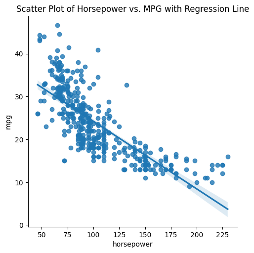

```python
# BEGIN SOLUTION

import seaborn as sns
import matplotlib.pyplot as plt

#Using seaborn's lmplot to create the scatter plot with a regression line
sns.lmplot(x='horsepower', y='mpg', data=df)

plt.title('Scatter Plot of Horsepower vs. MPG with Regression Line')
plt.show()


# END SOLUTION
```

### c) Use the `plot_fit` function from statsmodels library to produce diagnostic plots of the least squares regression fit. Comment on any problems you see with the fit.

Link to plot_fit:

https://www.statsmodels.org/dev/generated/statsmodels.graphics.regressionplots.plot_fit.html

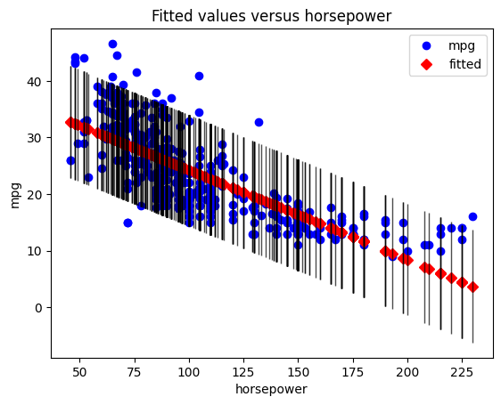

```python
# BEGIN SOLUTION

sm.graphics.plot_fit(results, 'horsepower')
plt.show()

# END SOLUTION
```

## Question 5

This question involves the use of multiple linear regression on the Auto data set. Read the dataset first:

### a) Produce a scatterplot matrix using pairplot() from seaborn library which includes all of the variables in the data set

Link to pairplot: https://seaborn.pydata.org/generated/seaborn.pairplot.html

```python
!pip install --upgrade seaborn
!pip install --upgrade pandas
```

[output not shown]

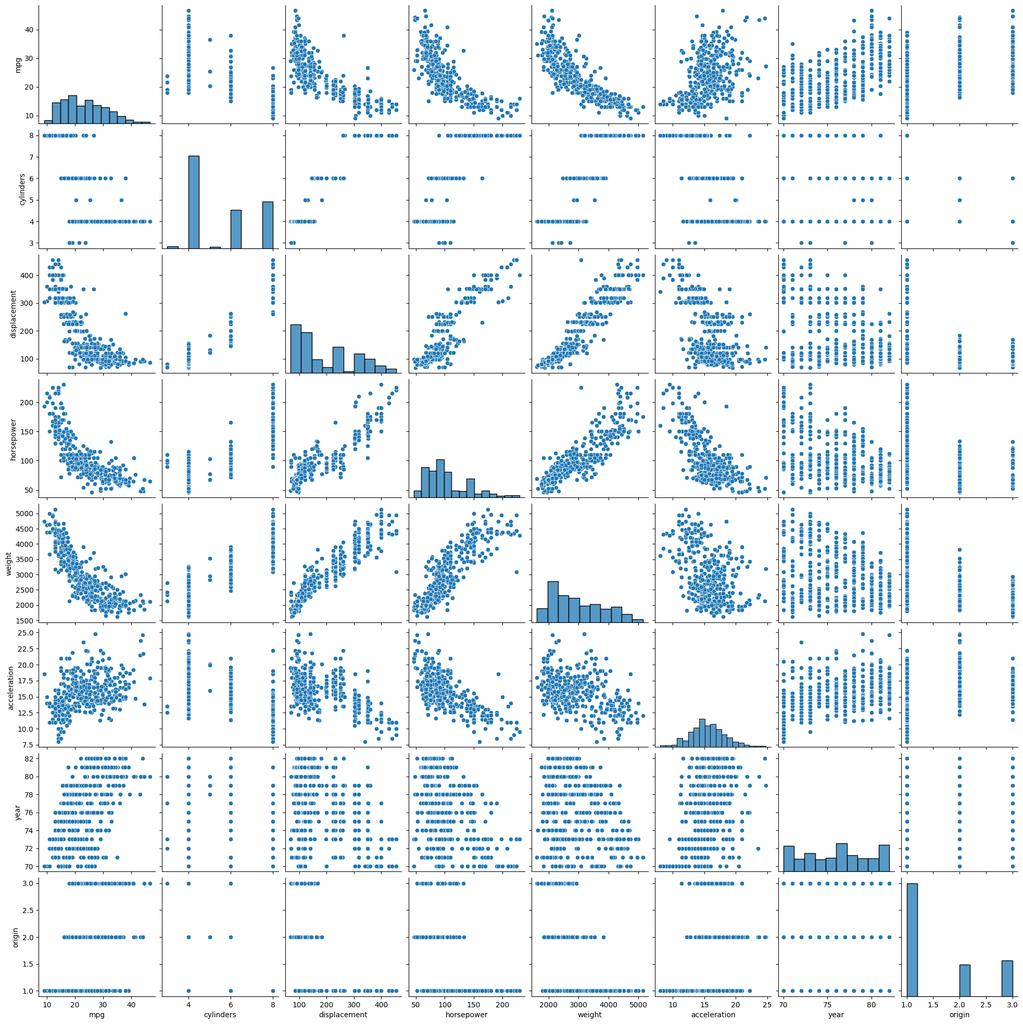

```python
# BEGIN SOLUTION

sns.pairplot(df)
plt.show()


# END SOLUTION
```

### b) Compute the matrix of correlations between the variables using the function `corr()`in pandas on the dataframe also plot the corresponding correlation matrix using `heatmap` function in seaborn

Links:

Corr() : https://pandas.pydata.org/docs/reference/api/pandas.DataFrame.corr.html

Heatmap : https://seaborn.pydata.org/generated/seaborn.heatmap.html

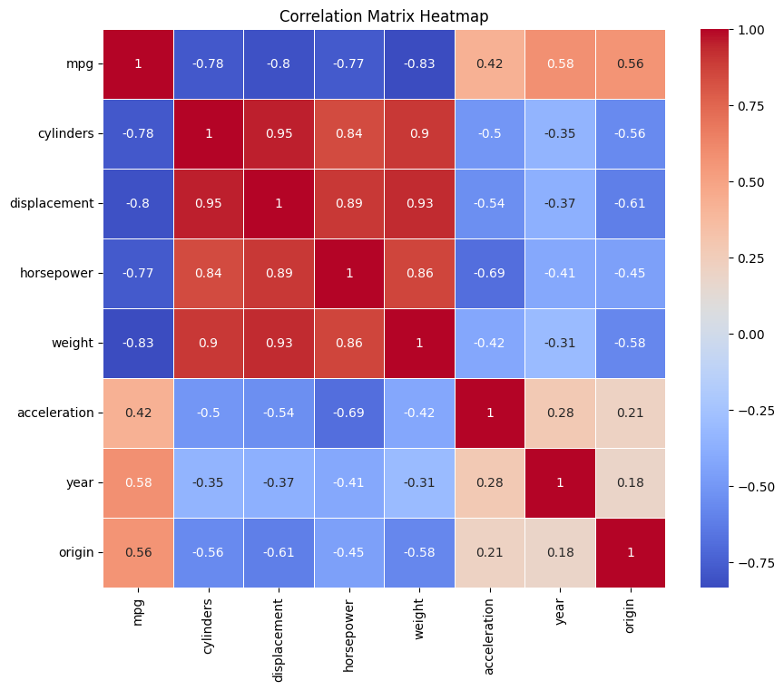

```python
# BEGIN SOLUTION
#Exclude non-numeric columns from the dataframe
numeric_df = df.select_dtypes(include=['number'])

#Computing  the correlation matrix
correlation_matrix = numeric_df.corr()

#Ploting the correlation matrix as a heatmap
plt.figure(figsize=(10, 8))
sns.heatmap(correlation_matrix, annot=True, cmap='coolwarm', linewidths=.5)
plt.title("Correlation Matrix Heatmap")
plt.show()



# END SOLUTION
```

Red Color indicate positive relationships. For example, newer cars tend to have better mileage (mpg) .So "mpg" and "year" are positively correlated.

Blue Color indicate negative relationships. Heavier cars tend to have lower mileage.So "mpg" and "weight" are negatively correlated.

White areas suggest no significant relationship.

The heatmap guides us to see how variables in the dataset are connected which is more significant for building a multiple linear regression model.

### c) Use the `ols()` function from statsmodels library to perform a multiple linear regression with mpg as the response and all other variables except name as the predictors. Use the `summary()` function from statsmodels to print the results. Use the questions below to comment on the output.

Reference to Statsmodels library and ols :

https://www.statsmodels.org/dev/generated/statsmodels.regression.linear_model.OLS.html#generated-statsmodels-regression-linear-model-ols--page-root

Links to summary:

https://www.statsmodels.org/devel/generated/statsmodels.regression.linear_model.OLSResults.summary.html

```python
# BEGIN SOLUTION

#Removing the 'name' column from the dataset
df = df.drop(columns=['name'])

#Defining the response variable (mpg) and predictors (all other columns)
X = df.drop(columns=['mpg'])
y = df['mpg']

#Creating a multiple linear regression model
model = sm.OLS(y, sm.add_constant(X))

#Fiting the model
results = model.fit()

print(results.summary())

# END SOLUTION
```

```
                            OLS Regression Results
==============================================================================
Dep. Variable:                    mpg   R-squared:                       0.822
Model:                            OLS   Adj. R-squared:                  0.818
Method:                 Least Squares   F-statistic:                     256.0
Date:                Tue, 26 Mar 2024   Prob (F-statistic):          2.41e-141
Time:                        18:17:15   Log-Likelihood:                -1037.4
No. Observations:                 397   AIC:                             2091.
Df Residuals:                     389   BIC:                             2123.
Df Model:                           7
Covariance Type:            nonrobust
================================================================================
                   coef    std err          t      P>|t|      [0.025      0.975]
--------------------------------------------------------------------------------
const          -18.7116      4.609     -4.060      0.000     -27.773      -9.650
cylinders       -0.4452      0.323     -1.380      0.168      -1.079       0.189
displacement     0.0189      0.007      2.524      0.012       0.004       0.034
horsepower      -0.0094      0.013     -0.709      0.479      -0.035       0.017
weight          -0.0067      0.001    -10.508      0.000      -0.008      -0.005
acceleration     0.1179      0.097      1.217      0.224      -0.073       0.308
year             0.7625      0.051     15.071      0.000       0.663       0.862
origin           1.3968      0.275      5.073      0.000       0.855       1.938
==============================================================================
Omnibus:                       29.782   Durbin-Watson:                   1.291
Prob(Omnibus):                  0.000   Jarque-Bera (JB):               47.819
Skew:                           0.506   Prob(JB):                     4.13e-11
Kurtosis:                       4.366   Cond. No.                     8.53e+04
==============================================================================

Notes:
[1] Standard Errors assume that the covariance matrix of the errors is correctly specified.
[2] The condition number is large, 8.53e+04. This might indicate that there are
strong multicollinearity or other numerical problems.
```

#### i. Is there a significant association between the predictors and the response?

Yes few predictors are significantly associated with the response (mpg) but not all of them.

This means that certain factors like "weight","origin" and "year" have a clear impact on mpg while others like "horsepower" and "acceleration" don't appear to be as important.

The overall model is statistically significant indicating that at least some predictors collectively affect the response variable.

#### ii. Which predictors appear to have a statistically significant relationship to the response?

The predictors "displacement," "weight," "year," and "origin" have a significant relationship with the response variable "mpg'.

These predictors are significant in explaining variations in mpg.

#### iii. What does the coefficient for the year variable suggest?

The coefficient for the "year" variable suggests that for each one-unit increase in the year the expected mpg of a car is estimated to increase by approximately 0.7625 units.

New cars have better fuel efficiency.

### d) Use the `plot_fit ()` function from statsmodels to produce diagnostic plots of the linear regression fit. Again, feel free to use any other package or function to create these plots. Comment on any problems you see with the fit. Do the residual plots suggest any unusually large outliers? Does the leverage plot identify any observations with unusually high leverage?

Link to plot_fit:

https://www.statsmodels.org/dev/generated/statsmodels.graphics.regressionplots.plot_fit.html

Link to residual plots:

https://www.statsmodels.org/dev/generated/statsmodels.graphics.regressionplots.plot_leverage_resid2.html

```python
#using plot_fit()
```

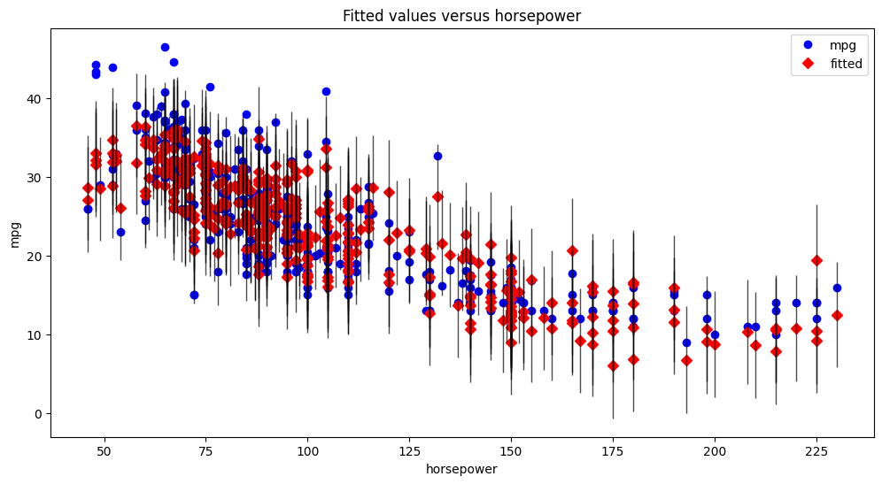

```python
# BEGIN SOLUTION

fig, ax = plt.subplots(figsize=(12, 6))
sm.graphics.plot_fit(results, exog_idx=3, ax=ax)  # Replace '2' with the index of the predictor variable you want to plot

plt.show()


# END SOLUTION
```

```python
#using plot_leverage_resid2
```

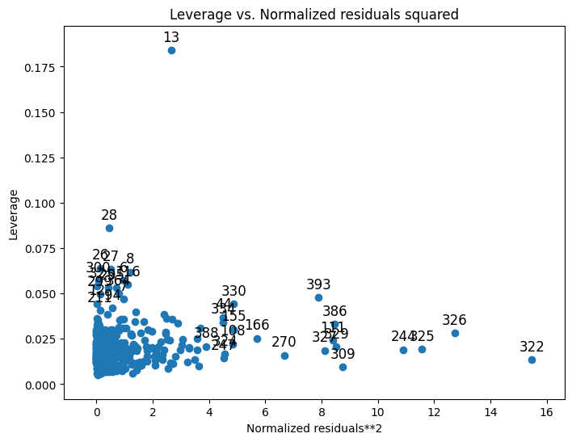

```python
# BEGIN SOLUTION

#Create a leverage-residual plot
fig, ax = plt.subplots(figsize=(8, 6))
sm.graphics.plot_leverage_resid2(results, ax=ax)
plt.show()

# END SOLUTION
```

In the above Levarage plot there is only one observation with the high leverage.